# [HCMUS - Leaderbug] AI4Code Competitions

Thành viên:

- Hoàng Minh Thanh (21C11029)
- Nguyễn Thành Thái (21C110026)
- Nguyễn Trần Khánh Nguyên (21C11017)
- Lê Trọng Tài (21C11022)
- Hoàng Ngọc Thạch (21C11025)

### Nội dung:

1. AI4Code Competitions

   1.1 Dataset

   `train`, `test`, `train_acestors`, `train_orders`

   1.2 Evaluation Ranking
2. Preprocessing
3. Model & training model

   3.1 CodeBERT

   3.2 PLBART

   3.3 Distilbert

   3.4 GraphBERT
4. Inference
5. Ensembling & submit

## Ranking trên leaderboard

Ngày 31 tháng 7 :

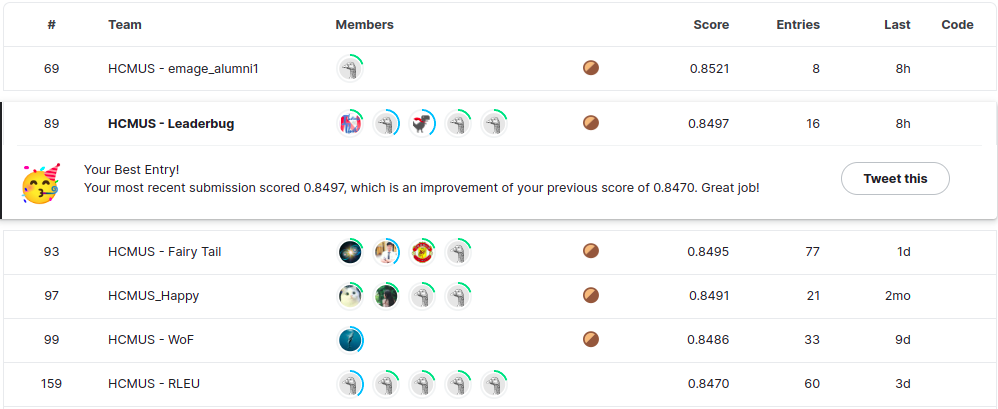

Score tăng từ 0.8497 lên **0.8514**

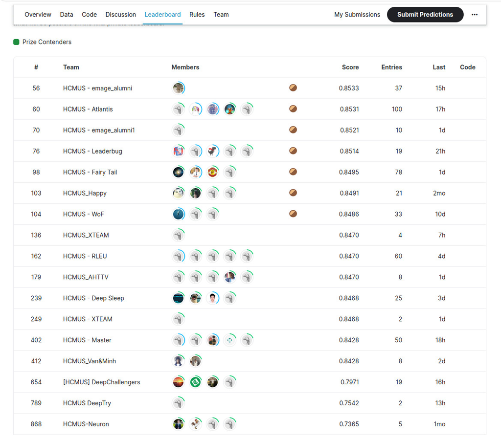

```python
IS_TRAINING = False
```

```python
import argparse
import gc
import json
import os
import random
import re
import sys
from bisect import bisect
from pathlib import Path

import matplotlib.pyplot as plt
import nltk
import numpy as np
import pandas as pd
import torch
import torch.nn as nn
import torch.nn.functional as F
from nltk.stem import WordNetLemmatizer
from scipy import sparse
from sklearn.metrics.pairwise import cosine_similarity
from sklearn.model_selection import GroupShuffleSplit
from torch.utils.data import DataLoader, Dataset
from tqdm import tqdm
from tqdm.contrib.concurrent import process_map
from tqdm.notebook import tqdm
from transformers import (AutoModel, AutoModelWithLMHead, AutoTokenizer,
                          RobertaConfig, RobertaModel, RobertaTokenizer)
nltk.download('wordnet')

pd.options.display.width = 180
pd.options.display.max_colwidth = 120
```

```python
PATH_DATA_DIR = Path('../input/AI4Code')

# CodeBERT
PATH_CODEBERT_MODEL = Path('../input/codebert-base/codebert-base')
PATH_CODEBERT_WEIGHT = Path('../input/ai4code-model')
PATH_CODEBERT_TOKENIZER = Path('../input/codebert-base/codebert-base')

# GraphCodeBERT
PATH_GRAPHCODEBERT_MODEL = Path('../input/graphcodebert-base-model')
PATH_GRAPHCODEBERT_WEIGHT = Path('../input/graphcodebert-base-8470')
PATH_GRAPHCODEBERT_TOKENIZER = Path('../input/graphcodebert-base-tokenizer')

# DistillBERT
PATH_DISTILL_BERT_MODEL = Path('../input/mymodelpairbertsmallpretrained/models/checkpoint-18000')
PATH_DISTILL_BERT_WEIGHT = Path('../input/mymodelbertsmallpretrained120000')
PATH_DISTILL_BERT_TOKENIZER = Path('../input/mymodelpairbertsmallpretrained/models/my_own_tokenizer')

# PLBART
PATH_PLBART_MODEL = Path('../input/uclanlp-plbart-base')
PATH_PLBART_WEIGHT = Path('../input/ai-uclanlp-plbart-base-epoch4')
PATH_PLBART_TOKENIZER = Path('../input/uclanlp-plbart-base')
```

### Common function

```python
# Đọc file notebook theo định dạng json và convert cột
def read_notebook(path):
    return (
        pd.read_json(
            path,
            dtype={'cell_type': 'category', 'source': 'str'})
        .assign(id=path.stem)
        .rename_axis('cell_id')
    )
```

```python
# Tạo sample cho cells để có kết quả tốt hơn
def sample_cells(cells, n):
    cells = [clean_code(cell) for cell in cells]
    if n >= len(cells): return [cell[:200] for cell in cells]
    else:
        results = []
        step = len(cells) / n
        idx = 0
        while int(np.round(idx)) < len(cells):
            results.append(cells[int(np.round(idx))])
            idx += step
        if cells[-1] not in results: results[-1] = cells[-1]
        return results

# Đọc đặc trưng của cells, tạo cột total_code, total_md, codes
def get_features(df):
    features = dict()
    df = df.sort_values("rank").reset_index(drop=True)
    for idx, sub_df in tqdm(df.groupby("id")):
        features[idx] = dict()
        total_md = sub_df[sub_df.cell_type == "markdown"].shape[0]
        code_sub_df = sub_df[sub_df.cell_type == "code"]
        total_code = code_sub_df.shape[0]
        codes = sample_cells(code_sub_df.source.values, 20)
        features[idx]["total_code"] = total_code
        features[idx]["total_md"] = total_md
        features[idx]["codes"] = codes
    return features
```

```python
# validate kết quả predict
def validate(model, val_loader):
    model.eval()
    tbar = tqdm(val_loader, file=sys.stdout)
    preds = []
    labels = []
    with torch.no_grad():
        for idx, data in enumerate(tbar):
            inputs, target = read_data(data)
            pred = model(*inputs)
            preds.append(pred.detach().cpu().numpy().ravel())
            labels.append(target.detach().cpu().numpy().ravel())
    return np.concatenate(labels), np.concatenate(preds)
```

```python
def clean_code(cell): return str(cell).replace("\\n", "\n")

def get_ranks(base, derived): return [base.index(d) for d in derived]

def read_data(data): return tuple(d.cuda() for d in data[:-1]), data[-1].cuda()
```

## 1. AI4Code Competitions

### 1.1 Dataset

Mục tiêu của cuộc thi này là để hiểu mối quan hệ giữa mã (Code) và chú thích (Comments) trong Notebooks của Python. Mục tiêu là để xắp xếp lại thứ tự của các ô Markdown trong một Notebook nhất định dựa trên thứ tự của các ô Code, thể hiện khả năng hiểu ngôn ngữ tự nhiên tương ứng tham chiếu đến đoạn mã nào.

Phía dưới là hình ảnh mô tả một ô chú thích (comment cell) tương ứng với một ô chứa mã (code cell) của nó.

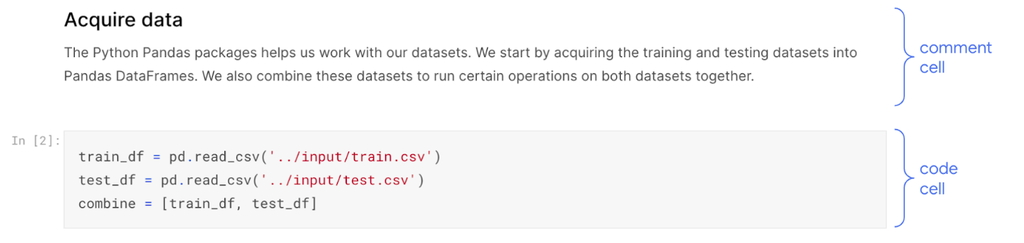

### Training Data

- **train/** - Thư mục chứa khoảng 140.000 tệp JSON với các tên tệp tương ứng với trường id trong tệp csv. Mỗi tệp chứa code và các cell markdown của sổ ghi chép Kaggle. Các code đã đúng thứ tự ban đầu của chúng. Các ô markdown đã được xáo trộn và đặt sau các cell.
- **train_orders.csv** - Cung cấp thứ tự chính xác của các cells cho mỗi Notebook trong thư mục train/..
  - **id** - thể hiện tên Notebook tương ứng với tập tin {id}.json.
  - **cell_order** - danh sách được phân tách bằng dấu cách về thứ tự ô chính xác được cung cấp theo thứ tự trong {id}.json.
- **train_ancestors.csv** - Trên Kaggle, người dùng có thể "fork" Notebook của người dùng khác để tạo phiên bản của riêng họ. Tệp này chứa lịch sử huấn luyện của các Notebook trong tập training. Không có tệp tương ứng cho test dataset.
  - **ancestor_id** - Xác định các bộ Notebooks có nguồn gốc chung hoặc "ancestor". Vì không có Notebook nào trong tập test có một ancestor trong tập training, bạn có thể thấy trường này được sử dụng như một yếu tố để nhóm khi khởi tạo bộ validation splits.
  - **parent_id** - Cho biết rằng một số version của notebook id đã được forked từ một số version của notebook parent_id. Notebook parent_id có thể có hoặc có thể không có trong dữ liệu huấn luyện. (Ví dụ: Nodebook cha có thể bị mất vì ai đó đã tách một Notebook riêng của họ.)

### 1.2 Evaluation Ranking

Các dự đoán được đánh giá bằng mối tương quan thứ hạng Kendall theo hệ số tau giữa thứ tự ô được dự đoán và thứ tự ô thật sự được tích lũy trong toàn bộ bộ sưu tập của những Notebooks tập thử nghiệm.

Chúng ta tính tổng số lần hoán đổi từ thứ tự ô dự đoán của bạn trên toàn bộ bộ sưu tập của notebooks tập thử nghiệm và tương tự với số lần hoán đổi trong trường hợp xấu nhất. Sau đó, chúng tôi tính toán mối tương quan Kendall tau như sau:

$$ K=1-4 \frac{\sum_{i} S_{i}}{\sum_{i} n_{i}\left(n_{i}-1\right)} $$

```
id,cell_order
0009d135ece78d,ddfd239c c6cd22db 1372ae9b ...
0010483c12ba9b,54c7cab3 fe66203e 7844d5f8 ...
0010a919d60e4f,aafc3d23 80e077ec b190ebb4 ...
0028856e09c5b7,012c9d02 d22526d1 3ae7ece3 ...
etc.
```

```python
def count_inversions(a):
    inversions = 0
    sorted_so_far = []
    for i, u in enumerate(a):
        j = bisect(sorted_so_far, u)
        inversions += i - j
        sorted_so_far.insert(j, u)
    return inversions
```

> Độ độ của cuộc thi dùng đó là đô đo Kendall tau.

> Độ đo kendall_tau sẽ đo số lần hoán đổi (tương tự như bubble sort) để đạt được kết quả thứ tự của các cell đúng

```python
def kendall_tau(ground_truth, predictions):
    total_inversions = 0
    total_2max = 0  # twice the maximum possible inversions across all instances
    for gt, pred in zip(ground_truth, predictions):
        ranks = [gt.index(x) for x in pred]  # rank predicted order in terms of ground truth
        total_inversions += count_inversions(ranks)
        n = len(gt)
        total_2max += n * (n - 1)
    return 1 - 4 * total_inversions / total_2max
```

## 2. Preprocessing

### Phần tiền xử lý dữ liệu đã được xử lý và lưu trữ ở data.

Nếu ở mode IS_TRAINING=False thì sẽ không cần phải preprocessing lại

**training/**

```python
PATH_PREPROCESSED = Path("../input/suicao-ai4code-baseline-preprocessed-data/preprocessed-data")
N_DATA = 100
if False:
    paths_train = list((PATH_DATA_DIR / 'train').glob('*.json'))[:N_DATA]
    notebooks_train = [
        read_notebook(path) for path in tqdm(paths_train, desc='Train NBs')
    ]
    df = (
        pd.concat(notebooks_train)
            .set_index('id', append=True)
            .swaplevel()
            .sort_index(level='id', sort_remaining=False)
    )
    df_orders_ = df_orders.to_frame().join(
        df.reset_index('cell_id').groupby('id')['cell_id'].apply(list),
        how='right',
    )

    ranks = {}
    for id_, cell_order, cell_id in df_orders_.itertuples():
        ranks[id_] = {'cell_id': cell_id, 'rank': get_ranks(cell_order, cell_id)}
    df_ranks = (
        pd.DataFrame
            .from_dict(ranks, orient='index')
            .rename_axis('id')
            .apply(pd.Series.explode)
            .set_index('cell_id', append=True)
    )

    df_ancestors = pd.read_csv(PATH_DATA_DIR / 'train_ancestors.csv', index_col='id')
    df = df.reset_index().merge(df_ranks, on=["id", "cell_id"]).merge(df_ancestors, on=["id"])
    df["pct_rank"] = df["rank"] / df.groupby("id")["cell_id"].transform("count")


# else:
#     train_df_mark = pd.read_csv(PATH_PREPROCESSED / "train.csv").drop("parent_id", axis=1).dropna().reset_index(drop=True)
# train_df_mark
```

```python
if False:
    NVALID = 0.1  # size of validation set
    splitter = GroupShuffleSplit(n_splits=1, test_size=NVALID, random_state=0)
    train_ind, val_ind = next(splitter.split(df, groups=df["ancestor_id"]))
    train_df = df.loc[train_ind].reset_index(drop=True)
    val_df = df.loc[val_ind].reset_index(drop=True)

    # Base markdown dataframes
    train_df_mark = train_df[train_df["cell_type"] == "markdown"].reset_index(drop=True)
    val_df_mark = val_df[val_df["cell_type"] == "markdown"].reset_index(drop=True)
    train_df_mark.to_csv("./data/train_mark.csv", index=False)
    val_df_mark.to_csv("./data/val_mark.csv", index=False)
    val_df.to_csv("./data/val.csv", index=False)
    train_df.to_csv("./data/train.csv", index=False)

    val_fts = get_features(val_df)
    json.dump(val_fts, open("./val_fts.json","wt"))
    train_fts = get_features(train_df)
    json.dump(train_fts, open("./train_fts.json","wt"))
```

**test/**

```python
paths_test = list((PATH_DATA_DIR / 'test').glob('*.json'))
notebooks_test = [
    read_notebook(path) for path in tqdm(paths_test, desc='Test NBs')
]
test_df = (
    pd.concat(notebooks_test)
    .set_index('id', append=True)
    .swaplevel()
    .sort_index(level='id', sort_remaining=False)
).reset_index()

test_df
```

**train_orders.csv**

```python
# Tách chuỗi cell_ids thành một danh sách
df_orders = pd.read_csv(
    PATH_DATA_DIR / 'train_orders.csv',
    index_col='id',
    squeeze=True,
).str.split()

df_orders
```

```python
if IS_TRAINING:
    grouped_df_orders = df_orders.to_frame().join(
        df.reset_index('cell_id').groupby('id')['cell_id'].apply(list),
        how='right',
    )

    df_orders_ = df_orders.to_frame().join(
        df.reset_index('cell_id')
        .groupby('id')['cell_id']
        .apply(list),
        how='right',
    )

    ranks = {}
    for id_, cell_order, cell_id in df_orders_.itertuples():
        ranks[id_] = {'cell_id': cell_id, 'rank': get_ranks(cell_order, cell_id)}
    df_ranks = (
        pd.DataFrame
            .from_dict(ranks, orient='index')
            .rename_axis('id')
            .apply(pd.Series.explode)
            .set_index('cell_id', append=True)
    )

    df_ancestors = pd.read_csv(data_dir / 'train_ancestors.csv', index_col='id')
    df = df.reset_index().merge(df_ranks, on=["id", "cell_id"]).merge(df_ancestors, on=["id"])
    df["pct_rank"] = df["rank"] / df.groupby("id")["cell_id"].transform("count")
    grouped_df_orders = df_orders.to_frame().join(
        df.reset_index('cell_id').groupby('id')['cell_id'].apply(list),
        how='right',
    )
```

```python
if IS_TRAINING:
    ranks = {}
    for id_, cell_order, cell_id in df_orders_.itertuples():
        ranks[id_] = {'cell_id': cell_id, 'rank': get_ranks(cell_order, cell_id)}
    df_ranks = (
        pd.DataFrame
            .from_dict(ranks, orient='index')
            .rename_axis('id')
            .apply(pd.Series.explode)
            .set_index('cell_id', append=True)
    )
```

**train_ancestors.csv**

```python
df_ancestors = pd.read_csv(PATH_DATA_DIR / 'train_ancestors.csv', index_col='id')
df_ancestors
```

## 3. Model & training model

```python
def predict_caller(args): return predict(args[0], args[1], args[2], args[3])


def predict(model_path, ckpt_path, path_tokenizer, submission_version):
    import gc
    import json
    import sys
    import os
    import numpy as np
    import pandas as pd
    from tqdm import tqdm
    from pathlib import Path
    from scipy import sparse

    paths_test = list((PATH_DATA_DIR / 'test').glob('*.json'))
    notebooks_test = [
        read_notebook(path) for path in tqdm(paths_test, desc='Test NBs')
    ]
    test_df = (
        pd.concat(notebooks_test)
        .set_index('id', append=True)
        .swaplevel()
        .sort_index(level='id', sort_remaining=False)
    ).reset_index()
    test_df["rank"] = test_df.groupby(["id", "cell_type"]).cumcount()
    test_df["pred"] = test_df.groupby(["id", "cell_type"])[
        "rank"].rank(pct=True)

    import torch
    import torch.nn as nn
    import torch.nn.functional as F
    from torch.utils.data import DataLoader, Dataset
    from transformers import AutoModel, AutoTokenizer

    # Các mô hình markdown đều tương tự nhau
    class MarkdownModel(nn.Module):
        def __init__(self, model_path):
            super(MarkdownModel, self).__init__()
            self.model = AutoModel.from_pretrained(model_path)
            self.top = nn.Linear(769, 1)

        def forward(self, ids, mask, fts):
            x = self.model(ids, mask)[0]
            x = self.top(torch.cat((x[:, 0, :], fts), 1))
            return x

    class MarkdownDataset(Dataset):
        def __init__(self, df, model_name_or_path, total_max_len, md_max_len, fts, tokenizer):
            super().__init__()
            self.df = df.reset_index(drop=True)
            self.md_max_len = md_max_len
            self.total_max_len = total_max_len  # maxlen allowed by model config
            self.tokenizer = AutoTokenizer.from_pretrained(tokenizer)
            self.fts = fts

        def __getitem__(self, index):
            row = self.df.iloc[index]

            inputs = self.tokenizer.encode_plus(
                row.source,
                None,
                add_special_tokens=True,
                max_length=self.md_max_len,
                padding="max_length",
                return_token_type_ids=True,
                truncation=True
            )
            code_inputs = self.tokenizer.batch_encode_plus(
                [str(x) for x in self.fts[row.id]["codes"]],
                add_special_tokens=True,
                max_length=23,
                padding="max_length",
                truncation=True
            )
            n_md = self.fts[row.id]["total_md"]
            n_code = self.fts[row.id]["total_code"]
            if n_md + n_code == 0:
                fts = torch.FloatTensor([0])
            else:
                fts = torch.FloatTensor([n_md / (n_md + n_code)])

            ids = inputs['input_ids']
            for x in code_inputs['input_ids']:
                ids.extend(x[:-1])
            ids = ids[:self.total_max_len]
            if len(ids) != self.total_max_len:
                ids = ids + [self.tokenizer.pad_token_id, ] * \
                    (self.total_max_len - len(ids))
            ids = torch.LongTensor(ids)

            mask = inputs['attention_mask']
            for x in code_inputs['attention_mask']:
                mask.extend(x[:-1])
            mask = mask[:self.total_max_len]
            if len(mask) != self.total_max_len:
                mask = mask + [self.tokenizer.pad_token_id, ] * \
                    (self.total_max_len - len(mask))
            mask = torch.LongTensor(mask)

            assert len(ids) == self.total_max_len

            return ids, mask, fts, torch.FloatTensor([row.pct_rank])

        def __len__(self):
            return self.df.shape[0]

    model = MarkdownModel(model_path)
    model = model.cuda()
    model.eval()
    model.load_state_dict(torch.load(ckpt_path))
    BS = 32
    NW = 8
    MAX_LEN = 64
    test_df["pct_rank"] = 0
    test_fts = get_features(test_df)
    test_ds = MarkdownDataset(test_df[test_df["cell_type"] == "markdown"].reset_index(
        drop=True), md_max_len=64, total_max_len=512, model_name_or_path=model_path, fts=test_fts, tokenizer=path_tokenizer)
    test_loader = DataLoader(test_ds, batch_size=BS, shuffle=False, num_workers=NW,
                             pin_memory=False, drop_last=False)
    _, y_test = validate(model, test_loader)
    model.to(torch.device('cpu'))
    torch.cuda.empty_cache()
    del model, test_loader, test_ds
    gc.collect()

    test_df.loc[test_df["cell_type"] == "markdown", "pred"] = y_test
    sub_df = test_df.sort_values("pred").groupby(
        "id")["cell_id"].apply(lambda x: " ".join(x)).reset_index()
    sub_df.rename(columns={"cell_id": "cell_order"}, inplace=True)
    sub_df.head()
    sub_df.to_csv(f"submission_{submission_version}.csv", index=False)

    del test_df, paths_test, notebooks_test, test_fts, model_path, ckpt_path, sub_df
    del json, np, pd, tqdm, Path, sparse, torch, sys, os, nn, F, AutoModel, AutoTokenizer
    gc.collect()
```

### 3.1 CodeBERT

Paper : [CodeBERT A Pre-Trained Model for Programming and Natural Languages](https://arxiv.org/abs/2002.08155)

Model : microsoft/codebert-base (https://huggingface.co/microsoft/codebert-base)

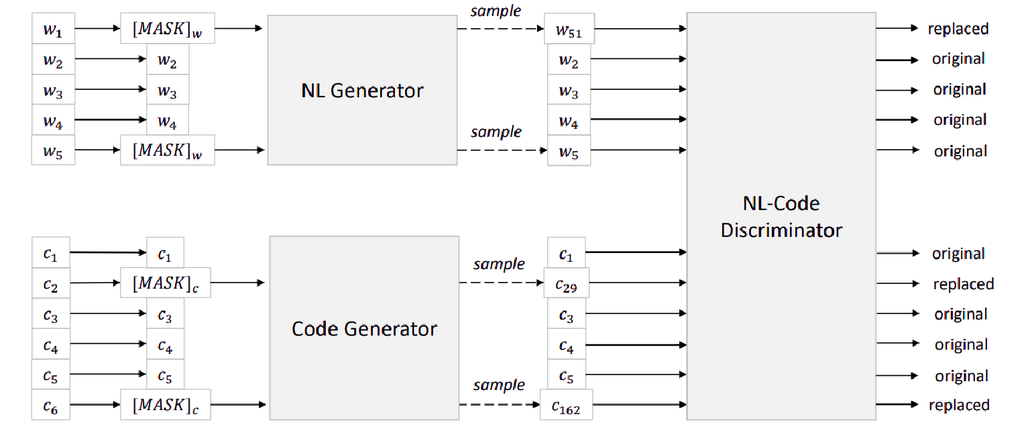

Mô hình CodeBERT dựa trên nền tảng là mô hình RoBERTa

https://github.com/huggingface/transformers/blob/main/src/transformers/models/roberta/modeling_roberta.py

Đầu tiên phần markdown và code cell sẽ được biểu diễn thành hai vector khác nhau:

Gồm có :

### 1. Objective #1: Masked Language Modeling (MLM): Là các đoạn markdown mô tả đoạn code được thay thế (masking) lần lượt từ trái qua phải và cần phải dự đoán để tính hàm loss ở cuối mô hình

$$ \begin{aligned} m_{i}^{w} & \sim \operatorname{unif}\{1,|\boldsymbol{w}|\} \text { for } i=1 \text { to }|\boldsymbol{w}| \\ m_{i}^{c} & \sim \operatorname{unif}\{1,|\boldsymbol{c}|\} \text { for } i=1 \text { to }|\boldsymbol{c}| \\ \boldsymbol{w}^{\text {masked }} &=\operatorname{REPLACE}\left(\boldsymbol{w}, \boldsymbol{m}^{\boldsymbol{w}},[M A S K]\right) \\ \boldsymbol{c}^{\text {masked }} &=\operatorname{REPLACE}\left(\boldsymbol{c}, \boldsymbol{m}^{c},[M A S K]\right) \\ \boldsymbol{x} &=\boldsymbol{w}+\boldsymbol{c} \end{aligned} $$

Hàm loss được tính theo công thức sau :

$$ \mathcal{L}_{\mathrm{MLM}}(\theta)=\sum_{i \in \boldsymbol{m}^{\boldsymbol{w}} \cup \boldsymbol{m}^{c}}-\log p^{D_{1}}\left(x_{i} \boldsymbol{w}^{\text {masked }}, \boldsymbol{c}^{\text {masked }}\right) $$

### 2. Objective #2: Replaced Token Detection (RTD) : Là các đoạn code được thay thế (masking) cần phải dự đoán, được thay thế lần lượt từ trái qua phải. Và cũng được dự đoán ở cuối mô hình.

$$ \begin{aligned} \hat{w}_{i} \sim p^{G_{w}}\left(w_{i} \mid \boldsymbol{w}^{\text {masked }}\right) \text { for } i \in \boldsymbol{m}^{\boldsymbol{w}} \\ \hat{c_{i}} \sim p^{G_{c}}\left(c_{i} \mid \boldsymbol{c}^{\text {masked }}\right) \text { for } i \in \boldsymbol{m}^{\boldsymbol{c}} \\ \boldsymbol{w}^{\text {corrupt }}=\operatorname{REPLACE}\left(\boldsymbol{w}, \boldsymbol{m}^{\boldsymbol{w}}, \hat{\boldsymbol{w}}\right) \\ \boldsymbol{c}^{\text {corrupt }}=\operatorname{REPLACE}\left(\boldsymbol{c}, \boldsymbol{m}^{\boldsymbol{c}}, \hat{\boldsymbol{c}}\right) \\ \boldsymbol{x}^{\text {corrupt }}=\boldsymbol{w}^{\text {corrupt }}+\boldsymbol{c}^{\text {corrupt }} \end{aligned} $$

Hàm loss của Replace Token Detection được tính như sau:

$$ \begin{aligned} \mathcal{L}_{\mathrm{RTD}}(\theta)=& \sum_{i=1}^{|\boldsymbol{w}|+|\boldsymbol{c}|}\left(\delta(i) \log p^{D_{2}}\left(\boldsymbol{x}^{\mathrm{corrupt}}, i\right)+\right.\\ &\left.(1-\delta(i))\left(1-\log p^{D_{2}}\left(\boldsymbol{x}^{\mathrm{corrupt}}, i\right)\right)\right) \\ \delta(i)=& \begin{cases}1, & \text { if } x_{i}^{\text {corrupt }}=x_{i} \\ 0, & \text { otherwise. }\end{cases} \end{aligned} $$

Hàm loss cuối cùng giữa Masked Language Modeling (MLM) và Replaced Token Detection (RTD) được tính như sau:

$$ \min _{\theta} \mathcal{L}_{\mathrm{MLM}}(\theta)+\mathcal{L}_{\mathrm{RTD}}(\theta) $$

```python
CODEBERT_MODEL = PATH_CODEBERT_MODEL / "."
CODEBERT_TOKENIZER = PATH_CODEBERT_TOKENIZER / "."
CODEBERT_WEIGHT = PATH_CODEBERT_WEIGHT / "model.bin"

# submission_codebert.csv
process_map(predict_caller, [(CODEBERT_MODEL, CODEBERT_WEIGHT, CODEBERT_TOKENIZER, "codebert")])[0]
gc.collect()
```

### 3.2 PLBART

Paper : [Unified Pre-training for Program Understanding and Generation](https://arxiv.org/pdf/2103.06333)

HuggingFace Model : uclanlp/plbart-base (https://huggingface.co/uclanlp/plbart-base)

Docs : https://huggingface.co/docs/transformers/model_doc/plbart

Mã nguồn gốc : https://github.com/wasiahmad/PLBART

```python
PLBART_MODEL = PATH_PLBART_MODEL / "."
PLBART_WEIGHT = PATH_PLBART_WEIGHT / "model(1).bin"
PLBART_TOKENIZER = PATH_PLBART_TOKENIZER / "."

process_map(predict_caller, [(PLBART_MODEL, PLBART_WEIGHT, PLBART_TOKENIZER,"plbart")])[0]
gc.collect()
```

### 3.3 DistilBERT

Paper :

- DistilBERT, a distilled version of BERT: smaller, faster, cheaper and lighter - https://arxiv.org/abs/1910.01108
- Multi-Stage Document Ranking with BERT - https://arxiv.org/pdf/1910.14424.pdf

BERT : [BERT: Pre-training of Deep Bidirectional Transformers for Language Understanding](https://arxiv.org/pdf/1810.04805.pdf)

Model File : https://huggingface.co/distilbert-base-uncased/tree/main

Docs : https://huggingface.co/distilbert-base-uncased

```python
# BERT_PATH = "../input/huggingface-bert-variants/distilbert-base-uncased/distilbert-base-uncased"
NUM_TRAIN = 1000

paths_train = list((PATH_DATA_DIR / 'train').glob('*.json'))[:NUM_TRAIN]
# paths_train = list((PATH_DATA_DIR / 'train').glob('*.json'))
notebooks_train = [
    read_notebook(path) for path in tqdm(paths_train, desc='Train NBs')
]
df = (
    pd.concat(notebooks_train)
    .set_index('id', append=True)
    .swaplevel()
    .sort_index(level='id', sort_remaining=False)
)

df
```

```python
# Get an example notebook
nb_id = df.index.unique('id')[6]
print('Notebook:', nb_id)

print("The disordered notebook:")
nb = df.loc[nb_id, :]
display(nb)
print()
```

```python
df_orders_ = df_orders.to_frame().join(
    df.reset_index('cell_id').groupby('id')['cell_id'].apply(list),
    how='right',
)
df_orders_
```

```python
cell_order = df_orders.loc[nb_id]

print("The ordered notebook:")
nb.loc[cell_order, :]
```

```python
def get_ranks(base, derived):
    return [base.index(d) for d in derived]

cell_ranks = get_ranks(cell_order, list(nb.index))
nb.insert(0, 'rank', cell_ranks)

nb
```

```python
ranks = {}
for id_, cell_order, cell_id in df_orders_.itertuples():
    ranks[id_] = {'cell_id': cell_id, 'rank': get_ranks(cell_order, cell_id)}

df_ranks = (
    pd.DataFrame
    .from_dict(ranks, orient='index')
    .rename_axis('id')
    .apply(pd.Series.explode)
    .set_index('cell_id', append=True)
)

df_ranks
```

```python
df = df.reset_index().merge(df_ranks, on=["id", "cell_id"]).merge(df_ancestors, on=["id"])
df
```

```python
df["pct_rank"] = df["rank"] / df.groupby("id")["cell_id"].transform("count")
df["pct_rank"].hist(bins=10)
```

```python
dict_cellid_source = dict(zip(df['cell_id'].values, df['source'].values))

stemmer = WordNetLemmatizer()

def preprocess_text(document):
        # Xóa tất cả các kỹ tự đặc biệt
        document = re.sub(r'\W', ' ', str(document))

        # Xóa tất cả ký tự đơn
        document = re.sub(r'\s+[a-zA-Z]\s+', ' ', document)

        # Xóa tất cả ký tự bắt đầu với một chữ cái
        document = re.sub(r'\^[a-zA-Z]\s+', ' ', document)

        # Substituting multiple spaces with single space
        document = re.sub(r'\s+', ' ', document, flags=re.I)

        # Xóa prefix 'b'
        document = re.sub(r'^b\s+', '', document)

        # Chuyển sang lowercase
        document = document.lower()
        #return document

        # Lemmatization
        tokens = document.split()
        tokens = [stemmer.lemmatize(word) for word in tokens]
        tokens = [word for word in tokens if len(word) > 3]

        preprocessed_text = ' '.join(tokens)
        return preprocessed_text


def preprocess_df(df):
    """
    This function is for processing sorce of notebook
    returns preprocessed dataframe
    """
    return [preprocess_text(message) for message in df.source]

df.source = df.source.apply(preprocess_text)
```

```python
# from sklearn.model_selection import GroupShuffleSplit
NVALID = 0.1  # size of validation set

splitter = GroupShuffleSplit(n_splits=1, test_size=NVALID, random_state=0)

train_ind, val_ind = next(splitter.split(df, groups=df["ancestor_id"]))

train_df = df.loc[train_ind].reset_index(drop=True)
val_df = df.loc[val_ind].reset_index(drop=True)
```

```python
# Tạo ra bộ ba để đưa vào đồ thị
def generate_triplet(df, mode='train'):
    triplets = []
    ids = df.id.unique()
    random_drop = np.random.random(size=10000) > 0.9
    count = 0

    for id, df_tmp in tqdm(df.groupby('id')):
        df_tmp_markdown = df_tmp[df_tmp['cell_type'] == 'markdown']

        df_tmp_code = df_tmp[df_tmp['cell_type'] == 'code']
        df_tmp_code_rank = df_tmp_code['rank'].values
        df_tmp_code_cell_id = df_tmp_code['cell_id'].values

        for cell_id, rank in df_tmp_markdown[['cell_id', 'rank']].values:
            labels = np.array([(r == (rank+1))
                              for r in df_tmp_code_rank]).astype('int')

            for cid, label in zip(df_tmp_code_cell_id, labels):
                count += 1
                if label == 1:
                    triplets.append([cell_id, cid, label])
                    # triplets.append( [cid, cell_id, label] )
                elif mode == 'test':
                    triplets.append([cell_id, cid, label])
                    # triplets.append( [cid, cell_id, label] )
                elif random_drop[count % 10000]:
                    triplets.append([cell_id, cid, label])
                    # triplets.append( [cid, cell_id, label] )

    return triplets


triplets = generate_triplet(train_df)
val_triplets = generate_triplet(val_df, mode='test')
```

```
['c40a4f80', 'cf0895a6', 0],
['c40a4f80', '06433c90', 0],
['c40a4f80', '9e7da027', 1],
['c40a4f80', '5a8cacef', 0],
```

```python
val_df.head()
```

```python
MAX_LEN = 128

DISTILL_BERT_MODEL = PATH_DISTILL_BERT_MODEL / '.'
DISTILL_BERT_WEIGHT = PATH_DISTILL_BERT_WEIGHT / 'my_own_model.bin'
DISTILL_BERT_TOKENIZER = PATH_DISTILL_BERT_TOKENIZER / '.'


class DistillBERTMarkdownModel(nn.Module):
    def __init__(self):
        super(DistillBERTMarkdownModel, self).__init__()
#         self.distill_bert = AutoModel.from_pretrained("../input/mymodelpairbertsmallpretrained/models/checkpoint-18000")
        self.distill_bert = AutoModel.from_pretrained(DISTILL_BERT_MODEL)
        self.top = nn.Linear(512, 1)
        self.dropout = nn.Dropout(0.2)

    def forward(self, ids, mask):
        x = self.distill_bert(ids, mask)[0]
        x = self.dropout(x)
        x = self.top(x[:, 0, :])
        x = torch.sigmoid(x)
        return x

class DistillBERTCorpus(Dataset):
    def __init__(self, df, max_len, mode='train'):
        super().__init__()
        self.df = df
        self.max_len = max_len
        self.tokenizer = AutoTokenizer.from_pretrained(DISTILL_BERT_TOKENIZER, do_lower_case=True)
        self.mode=mode

    def __getitem__(self, index):
        row = self.df[index]

        label = row[-1]

        txt = dict_cellid_source[row[0]] + '[SEP]' + dict_cellid_source[row[1]]

        inputs = self.tokenizer.encode_plus(
            txt,
            None,
            add_special_tokens=True,
            max_length=self.max_len,
            padding="max_length",
            return_token_type_ids=True,
            truncation=True
        )
        ids = torch.LongTensor(inputs['input_ids'])
        mask = torch.LongTensor(inputs['attention_mask'])

        return ids, mask, torch.FloatTensor([label])

    def __len__(self):
        return len(self.df)
```

```python
def adjust_lr(optimizer, epoch):
    if epoch < 1:
        lr = 5e-5
    elif epoch < 2:
        lr = 1e-3
    elif epoch < 5:
        lr = 1e-4
    else:
        lr = 1e-5

    for p in optimizer.param_groups:
        p['lr'] = lr
    return lr

# Sử dụng Adam optimizer để optimize mô hình
def get_optimizer(net):
    optimizer = torch.optim.Adam(filter(lambda p: p.requires_grad, net.parameters()), lr=3e-4, betas=(0.9, 0.999), eps=1e-08)
    return optimizer

BS = 128 # batch size
NW = 16 # node worker
```

```python
test_df.source = test_df.source.apply(preprocess_text)
dict_cellid_source = dict(
    zip(test_df['cell_id'].values, test_df['source'].values))
test_df["rank"] = test_df.groupby(["id", "cell_type"]).cumcount()
test_df["pred"] = test_df.groupby(["id", "cell_type"])["rank"].rank(pct=False)
test_triplets = generate_triplet(test_df, mode='test')
```

```python
def validate(model, val_loader, mode='train'):
    model.eval()
    tbar = tqdm(val_loader, file=sys.stdout)
    preds = np.zeros(len(val_loader.dataset), dtype='float32')
    labels = []
    count = 0

    with torch.no_grad():
        for idx, data in enumerate(tbar):
            inputs, target = read_data(data)
            pred = model(inputs[0], inputs[1]).detach().cpu().numpy().ravel()
            preds[count:count+len(pred)] = pred
            count += len(pred)
            if mode == 'test':
                labels.append(target.detach().cpu().numpy().ravel())
    if mode == 'test':
        return preds
    else:
        return np.concatenate(labels), np.concatenate(preds)

test_df["pct_rank"] = 0
test_ds = DistillBERTCorpus(test_triplets, max_len=MAX_LEN)
test_loader = DataLoader(test_ds, batch_size=BS * 4, shuffle=False,
                         num_workers=NW, pin_memory=False, drop_last=False)

gc.collect()
len(test_ds), test_ds[0]
```

```python
model = DistillBERTMarkdownModel()
model = model.cuda()
model.load_state_dict(torch.load(DISTILL_BERT_WEIGHT))
y_test = validate(model, test_loader, mode='test')
```

```python
preds_copy = y_test
pred_vals = []
count = 0
for id, df_tmp in tqdm(test_df.groupby('id')):
    df_tmp_mark = df_tmp[df_tmp['cell_type'] == 'markdown']
    df_tmp_code = df_tmp[df_tmp['cell_type'] != 'markdown']
    df_tmp_code_rank = df_tmp_code['rank'].rank().values
    N_code = len(df_tmp_code_rank)
    N_mark = len(df_tmp_mark)

    preds_tmp = preds_copy[count:count+N_mark * N_code]

    count += N_mark * N_code

    for i in range(N_mark):
        pred = preds_tmp[i*N_code:i*N_code+N_code]

        softmax = np.exp((pred-np.mean(pred)) * 20) / \
            np.sum(np.exp((pred-np.mean(pred)) * 20))

        rank = np.sum(softmax * df_tmp_code_rank)
        pred_vals.append(rank)

del model
del test_triplets[:]
del dict_cellid_source
gc.collect()
```

```python
test_df.loc[test_df["cell_type"] == "markdown", "pred"] = pred_vals
sub_df = test_df.sort_values("pred").groupby(
    "id")["cell_id"].apply(lambda x: " ".join(x)).reset_index()
sub_df.rename(columns={"cell_id": "cell_order"}, inplace=True)

sub_df.to_csv("submission_distilbert.csv", index=False)
```

### 3.4 GraphCodeBERT

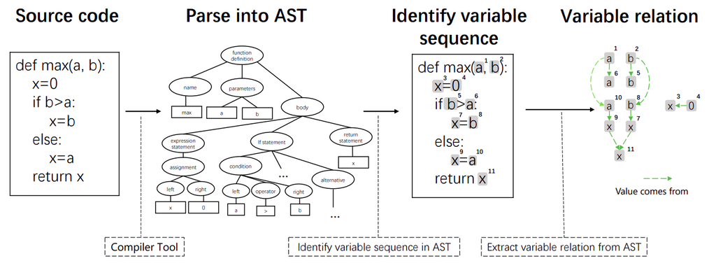

Paper : [GraphCodeBERT: Pre-training Code Representations with Data Flow](https://openreview.net/pdf?id=jLoC4ez43PZ)

Model : https://huggingface.co/microsoft/graphcodebert-base

Docs : https://github.com/microsoft/CodeBERT#graphcodebert

Mô hình GraphCodeBERT đầu tiên sẽ phân tích các ô cell có chứa code để sinh ra cây cú pháp **AST (Abstract syntax tree)**.

Sau đó mô hình xác định các biến, các phép gán, để xác định các câu cú phép một biến hoặc nhiều biến

Sau khi xác định các mối quan hệ của mô hình, ta tiến hành biểu diễn mối quan hệ của các biến được sinh ra từ cây cú pháp.

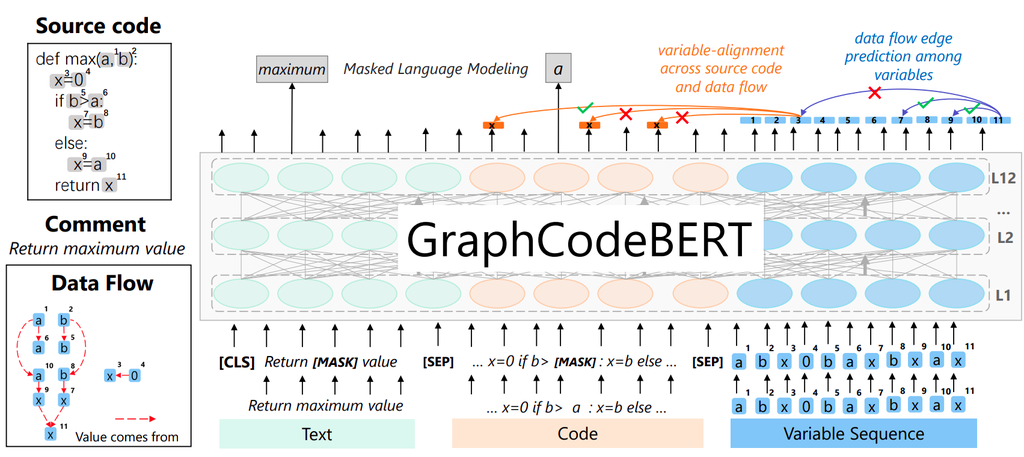

Ta tiến hành ghép chồng cả 3 đoạn gồm Text.

Code và Variable Sequence (Chuỗi các biến) để biểu diễn thành một vector và đưa vào mô hình BERT.

```
[CLS] _+_ Text [MASK] Text _+_  [SEP] _+_ Code [MASK] Code _+_ [SEP] _+_ Variable Sequence
```

1. Objective #1: Masked Language Modeling (MLM) : Là các đoạn markdown mô tả đoạn code được thay thế (masking) lần lượt từ trái qua phải và cần phải dự đoán để tính hàm loss ở cuối mô hình

$$ \begin{aligned} m_{i}^{w} & \sim \operatorname{unif}\{1,|\boldsymbol{w}|\} \text { for } i=1 \text { to }|\boldsymbol{w}| \\ m_{i}^{c} & \sim \operatorname{unif}\{1,|\boldsymbol{c}|\} \text { for } i=1 \text { to }|\boldsymbol{c}| \\ \boldsymbol{w}^{\text {masked }} &=\operatorname{REPLACE}\left(\boldsymbol{w}, \boldsymbol{m}^{\boldsymbol{w}},[M A S K]\right) \\ \boldsymbol{c}^{\text {masked }} &=\operatorname{REPLACE}\left(\boldsymbol{c}, \boldsymbol{m}^{\boldsymbol{c}},[M A S K]\right) \\ \boldsymbol{x} &=\boldsymbol{w}+\boldsymbol{c} \end{aligned} $$

Hàm loss được tính theo công thức sau :

$$ \mathcal{L}_{\mathrm{MLM}}(\theta)=\sum_{i \in \boldsymbol{m}^{\boldsymbol{w}} \cup \boldsymbol{m}^{\boldsymbol{c}}}-\log p^{D_{1}}\left(x_{i} \mid \boldsymbol{w}^{\text {masked }}, \boldsymbol{c}^{\text {masked }}\right) $$

$$ \begin{aligned} \hat{w}_{i} \sim p^{G_{w}}\left(w_{i} \mid \boldsymbol{w}^{\text {masked }}\right) \text { for } i \in \boldsymbol{m}^{\boldsymbol{w}} \\ \hat{c_{i}} \sim p^{G_{c}}\left(c_{i} \mid \boldsymbol{c}^{\text {masked }}\right) \text { for } i \in \boldsymbol{m}^{\boldsymbol{c}} \\ \boldsymbol{w}^{\text {corrupt }}=\operatorname{REPLACE}\left(\boldsymbol{w}, \boldsymbol{m}^{\boldsymbol{w}}, \hat{\boldsymbol{w}}\right) \\ \boldsymbol{c}^{\text {corrupt }}=\operatorname{REPLACE}\left(\boldsymbol{c}, \boldsymbol{m}^{\boldsymbol{c}}, \hat{\boldsymbol{c}}\right) \\ \boldsymbol{x}^{\text {corrupt }}=\boldsymbol{w}^{\text {corrupt }}+\boldsymbol{c}^{\text {corrupt }} \end{aligned} $$

Hàm loss của Replace Token Detection được tính như sau:

$$ \begin{aligned} \mathcal{L}_{\mathrm{RTD}}(\theta)=& \sum_{i=1}^{|\boldsymbol{w}|+|\boldsymbol{c}|}\left(\delta(i) \log p^{D_{2}}\left(\boldsymbol{x}^{\mathrm{corrupt}}, i\right)+\right.\\ &\left.(1-\delta(i))\left(1-\log p^{D_{2}}\left(\boldsymbol{x}^{\mathrm{corrupt}}, i\right)\right)\right) \\ \delta(i)=& \begin{cases}1, & \text { if } x_{i}^{\text {corrupt }}=x_{i} \\ 0, & \text { otherwise. }\end{cases} \end{aligned} $$

Hàm loss cuối cùng giữa Masked Language Modeling (MLM) và Replaced Token Detection (RTD) được tính như sau:

$$ \min _{\theta} \mathcal{L}_{\mathrm{MLM}}(\theta)+\mathcal{L}_{\mathrm{RTD}}(\theta) $$

```python
# GraphCodeBERT
GRAPHCODEBERT_MODEL = PATH_GRAPHCODEBERT_MODEL / '.'
GRAPHCODEBERT_WEIGHT = PATH_GRAPHCODEBERT_WEIGHT / 'graphcodebert-base-0.8470.bin'
GRAPHCODEBERT_TOKENIZER = PATH_GRAPHCODEBERT_TOKENIZER / '.'

total_max_len = 512
paths_test = list((PATH_DATA_DIR / 'test').glob('*.json'))
notebooks_test = [
    read_notebook(path) for path in tqdm(paths_test, desc='Test NBs')
]
test_df = (
    pd.concat(notebooks_test)
    .set_index('id', append=True)
    .swaplevel()
    .sort_index(level='id', sort_remaining=False)
).reset_index()
test_df["rank"] = test_df.groupby(["id", "cell_type"]).cumcount()
test_df["pred"] = test_df.groupby(["id", "cell_type"])["rank"].rank(pct=True)

test_fts = get_features(test_df)
```

```python
class GraphCodeBERTMarkdownModel(nn.Module):
    def __init__(self, path_model_or_huggingface_name):
        super(GraphCodeBERTMarkdownModel, self).__init__()
        self.model = AutoModel.from_pretrained(path_model_or_huggingface_name)
        self.top = nn.Linear(769, 1)

    def forward(self, ids, mask, fts):
        x = self.model(ids, mask)[0]
        x = self.top(torch.cat((x[:, 0, :], fts),1))
        return x

class GraphCodeBERTCorpus(Dataset):
    def __init__(self, df, tokenizer_path, total_max_len, md_max_len, fts):
        super().__init__()
        self.df = df.reset_index(drop=True)
        self.md_max_len = md_max_len
        self.total_max_len = total_max_len  # maxlen allowed by model config
        self.tokenizer = AutoTokenizer.from_pretrained(tokenizer_path)
        self.fts = fts

    def __getitem__(self, index):
        row = self.df.iloc[index]

        inputs = self.tokenizer.encode_plus(
            row.source,
            None,
            add_special_tokens=True,
            max_length=self.md_max_len,
            padding="max_length",
            return_token_type_ids=True,
            truncation=True
        )
        code_inputs = self.tokenizer.batch_encode_plus(
            [str(x) for x in self.fts[row.id]["codes"]],
            add_special_tokens=True,
            max_length=23,
            padding="max_length",
            truncation=True
        )
        n_md = self.fts[row.id]["total_md"]
        n_code = self.fts[row.id]["total_code"]
        if n_md + n_code == 0:
            fts = torch.FloatTensor([0])
        else:
            fts = torch.FloatTensor([n_md / (n_md + n_code)])

        ids = inputs['input_ids']
        for x in code_inputs['input_ids']:
            ids.extend(x[:-1])
        ids = ids[:self.total_max_len]
        if len(ids) != self.total_max_len:
            ids = ids + [self.tokenizer.pad_token_id, ] * (self.total_max_len - len(ids))
        ids = torch.LongTensor(ids)

        mask = inputs['attention_mask']
        for x in code_inputs['attention_mask']:
            mask.extend(x[:-1])
        mask = mask[:self.total_max_len]
        if len(mask) != self.total_max_len:
            mask = mask + [self.tokenizer.pad_token_id, ] * (self.total_max_len - len(mask))
        mask = torch.LongTensor(mask)

        assert len(ids) == self.total_max_len

        return ids, mask, fts, torch.FloatTensor([row.pct_rank])

    def __len__(self):
        return self.df.shape[0]


def validate(model, val_loader):
    model.eval()
    tbar = tqdm(val_loader, file=sys.stdout)
    preds = []
    labels = []
    with torch.no_grad():
        for idx, data in enumerate(tbar):
            inputs, target = read_data(data)
            pred = model(*inputs)
            preds.append(pred.detach().cpu().numpy().ravel())
            labels.append(target.detach().cpu().numpy().ravel())

    return np.concatenate(labels), np.concatenate(preds)
```

```python
def predict(model_path, ckpt_path, tokenizer_path):
    model = GraphCodeBERTMarkdownModel(model_path)
    model = model.to('cuda:0')
    model.eval()
    model.load_state_dict(torch.load(ckpt_path, map_location='cuda:0'))
    BS = 32
    NW = 8
    MAX_LEN = 64
    test_df["pct_rank"] = 0
    test_ds = GraphCodeBERTCorpus(test_df[test_df["cell_type"] == "markdown"].reset_index(drop=True),
                              md_max_len=64,
                              tokenizer_path = tokenizer_path,
                              total_max_len = total_max_len,
                              fts=test_fts)
    test_loader = DataLoader(test_ds, batch_size=BS,
                             shuffle=False,
                             num_workers=NW,
                             pin_memory=False,
                             drop_last=False)
    _, y_test = validate(model, test_loader)
    return y_test

y_test = predict(GRAPHCODEBERT_MODEL, GRAPHCODEBERT_WEIGHT, GRAPHCODEBERT_TOKENIZER)
```

```python
test_df.loc[test_df["cell_type"] == "markdown", "pred"] = y_test

sub_df = test_df.sort_values("pred").groupby("id")["cell_id"].apply(lambda x: " ".join(x)).reset_index()
sub_df.rename(columns={"cell_id": "cell_order"}, inplace=True)
sub_df.to_csv("submission_graphcodebert.csv", index=False)
sub_df.head()
```

Cuối cùng ta đọc và tổng hợp các submission để tiến hành ensemble để đạt kết quả tốt nhất

```python
df_1 = pd.read_csv('submission_distilbert.csv')
df_2 = pd.read_csv('submission_codebert.csv')
df_3 = pd.read_csv('submission_graphcodebert.csv')
df_4 = pd.read_csv('submission_plbart.csv')
```

```python
new_samples = []
for sample_idx in range(len(df_1)):
    sample_1 = {k: v for v, k in enumerate(df_1.iloc[sample_idx]['cell_order'].split(' '))}
    sample_2 = {k: v for v, k in enumerate(df_2.iloc[sample_idx]['cell_order'].split(' '))}
    sample_3 = {k: v for v, k in enumerate(df_3.iloc[sample_idx]['cell_order'].split(' '))}
    sample_4 = {k: v for v, k in enumerate(df_4.iloc[sample_idx]['cell_order'].split(' '))}
    for key in sample_1: sample_1[key] = ( (sample_1[key] * 0.120) + (sample_2[key] * 0.270) + (sample_3[key] * 0.370)+ (sample_4[key] * 0.240))
    new_samples.append(' '.join([i[0] for i in list(sorted(sample_1.items(), key=lambda x:x[1]))]))
df_1['cell_order'] = new_samples
```

# Final Submission

```python
df_1.to_csv('submission.csv', index = False)
df_1
```

# Report AI4Code:

1. Ban đầu chúng em tìm hiểu mô hình base dựa trên CodeBERT tham khảo source code của suicaokhoailang.
2. Sau đó chúng em kết hợp thêm mô hình DistillBERT của yuanzhezhou, và tiến hành enssemble kết quả dự đoán của hai mô hình.
3. Khi đạt được kết quả trên 80%, nhóm em tiếp tục cải tiến kết quả bằng cách kết hợp enssemble thêm mô hình GraphCodeBERT.
4. PLBART là bộ pre-train mới nhất được nhóm em dùng cho việc ensemble kết quả, nhóm em thử nhiều phương pháp khác nhau và submit để được kết quả tốt nhất.

Phần giải thích của từng mô hình được nhóm em trình bày ở trên